# tidycensus

[tidycensus](https://walker-data.com/tidycensus/) is an R package that allows users to interface with a select number of the US Census Bureau’s data APIs and return tidyverse-ready data frames, optionally with simple feature geometry included.

To get started working with tidycensus, users should load the package along with the [tidyverse](https://www.tidyverse.org/) package, and set their Census API key. A key can be obtained from http://api.census.gov/data/key_signup.html.

### Loading tidycensus package

```r
library(tidycensus)
library(tidyverse)
library(insight) #package to create exportable tables

#census_api_key("YOUR KEY GOES HERE")
```

*If you need to install the tidycensus package, run this line in the console: **install.packages(“tidycensus”)***

### Using the tidycensus package

The tidycensus package allows users to call on both decennial US Census APIs (2000, 2010, and 2020) and the 1-year and 5-year American Community Survey APIs.

- [get_decennial()](https://walker-data.com/tidycensus/reference/get_decennial.html)
- [get_acs()](https://walker-data.com/tidycensus/reference/get_acs.html)

#### Using `get_decennial()`

First, we will look at an example of using the decennial census. We will pull median age for counties in Connecticut in 2020 from the Demographic and Housing Characteristics summary file. If you wanted to pull data by towns in Connecticut you would use `geography = "county subdivision"`.

To search variables you can use the `load_variables()` function. For the decennial Census, possible dataset choices include `"pl"` for the redistricting files; `"dhc"` for the Demographic and Housing Characteristics file and `"dp"` for the Demographic Profile (2020 only).

```r
dec20_vars <- load_variables(2020, "dhc", cache = TRUE)
```

```r
median_age_dec <- get_decennial(
  geography = "County",
  #geography = "county subdivision",
  state = "Connecticut",
  variables = "P13_001N",
  year = 2020,
  sumfile = "dhc")
```

Here is a simple bar chart of the median age by county made with the [ggplot2](https://ggplot2.tidyverse.org/) package.

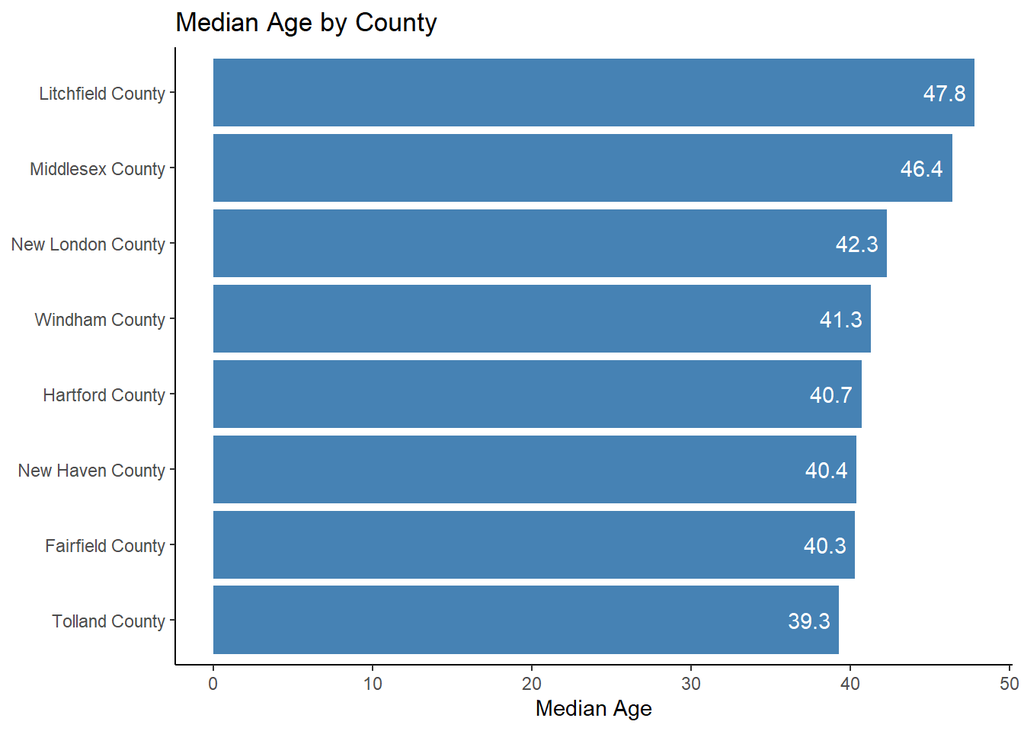

```r
#Dropping Connecticut from the name for a cleaner axis label on chart
median_age_dec_v2 <- median_age_dec %>%
  separate(NAME, sep = ",", c("County", NA))

median_age_dec_v2 %>%
  ggplot(aes(x = value, y = reorder(County, value))) +
  geom_bar(stat="identity", fill="steelblue") +
  labs(
    title = "Median Age by County",
    x = "Median Age",
    y = NULL
    ) +
  geom_text(aes(label = value), hjust = 1.2, colour = "white")+
  theme_classic()
```

Next, this is an example of pulling a whole table rather than specific variables. We will still look at Median Age but now break it down by sex.

```r
median_age_dec_table <- get_decennial(
  geography = "County",
  state = "Connecticut",
  table = "P13",
  year = 2020,
  sumfile = "dhc")
```

Instead of pulling the table in a long-format (the default), you can use `output = "wide"` to format the data so each variable has it’s own column.

```r
median_age_dec_table <- get_decennial(
  geography = "County",
  state = "Connecticut",
  table = "P13",
  year = 2020,
  sumfile = "dhc",
  output = "wide")
```

Now let’s create a output table for Median Age by Sex. We will use the [insight](https://cran.r-project.org/web/packages/insight/insight.pdf) package to create an exportable formatted table.

```r
#Dropping Connecticut from the name for a cleaner chart
median_age_dec_table_v2 <- median_age_dec_table %>%
  separate(NAME, sep = ",", c("County", NA)) %>%
  rename(`Median Age All` = P13_001N, `Median Age Male`  = P13_002N, `Median Age Female`  = P13_003N) %>%
  select(!GEOID)

export_table(median_age_dec_table_v2, format = "md") #using the Insights package and markdown format
```

| County | Median Age All | Median Age Male | Median Age Female |
| --- | --- | --- | --- |
| Fairfield County | 40.30 | 38.90 | 41.60 |
| Hartford County | 40.70 | 39.10 | 42.30 |
| Litchfield County | 47.80 | 46.40 | 49.00 |
| Middlesex County | 46.40 | 44.90 | 47.80 |
| New Haven County | 40.40 | 38.90 | 41.80 |
| New London County | 42.30 | 40.50 | 44.10 |
| Tolland County | 39.30 | 38.10 | 40.50 |
| Windham County | 41.30 | 40.20 | 42.70 |

#### Using `get_acs()`

Next, we will look at an example of using the American Community Survey (ACS). We will pull median household income for the COGs (county equivalents) in Connecticut in 2022 from the 5-Year ACS.

To search variables you can use the `load_variables()` function. For the 1-year estimates,include `"acs1"`. For the 5-year estimates, include`"acs5"`.

```r
ACS22_vars <- load_variables(2022, "acs5", cache = TRUE)
```

`get_acs()` defaults to the 5-year ACS, but 1-year ACS data are available using `survey = "acs1"`.

```r
median_hh_income_acs <- get_acs(
  geography = "county",
  state = "Connecticut",
  variables = "B19013_001",
  year = 2022,
  survey = "acs5")
```

Here is a simple bar chart of the median household income by COG made with the [ggplot2](https://ggplot2.tidyverse.org/) package.

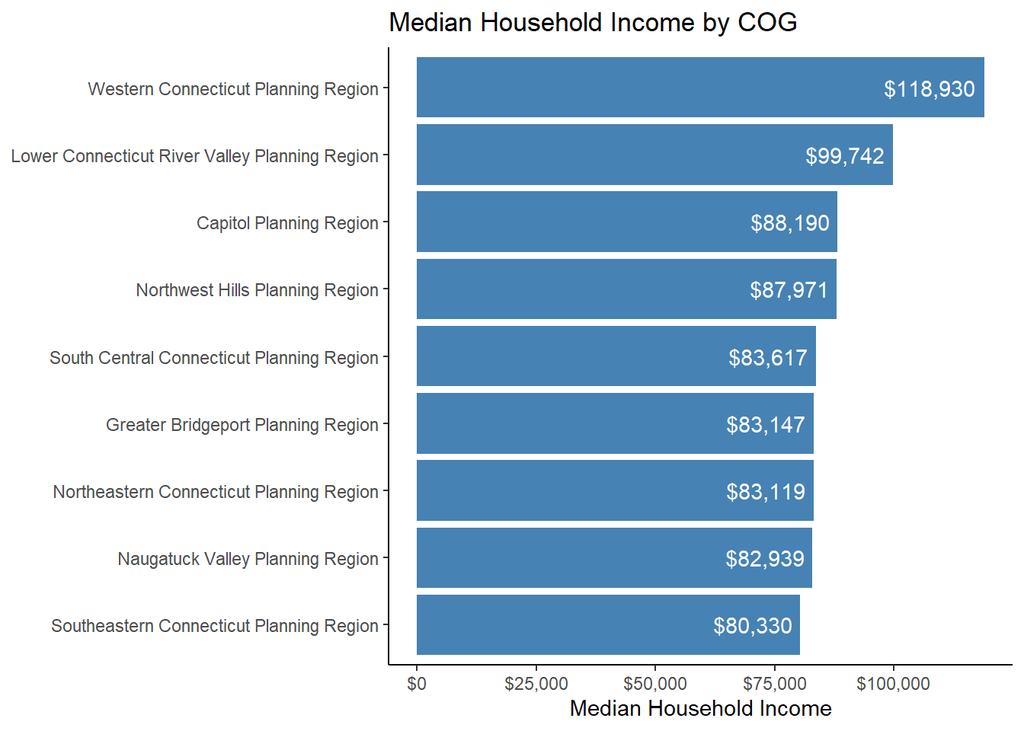

```r
#Dropping Connecticut from the name for a cleaner axis label on chart
median_hh_income_acs_V2 <- median_hh_income_acs %>%
  separate(NAME, sep = ",", c("CountyEqv", NA))

median_hh_income_acs_V2 %>%
  ggplot(aes(x = estimate, y = reorder(CountyEqv, estimate))) +
  geom_bar(stat="identity", fill="steelblue") +
  scale_x_continuous(labels = scales::dollar_format()) +
  labs(
    title = "Median Household Income by COG",
    x = "Median Household Income",
    y = NULL
    ) +
  geom_text(aes(label = scales::dollar_format()(estimate)), hjust = 1.1, colour = "white")+
  theme_classic()
```

Next, this is an example of pulling a whole table rather than specific variables. We will look at Median Age by Sex

```r
median_age_acs_table <- get_acs(
  geography = "county",
  state = "Connecticut",
  table = "B23013",
  year = 2022,
  survey = "acs5")
```

Instead of pulling the table in a long-format (the default), you can use `output = "wide"` to format the data so each variable has it’s own column.

```r
median_age_acs_table <- get_acs(
  geography = "county",
  state = "Connecticut",
  table = "B23013",
  year = 2022,
  survey = "acs5",
  output = "wide")
```

Now let’s create a output table for Median Age by Sex. We will use the [insight](https://cran.r-project.org/web/packages/insight/insight.pdf) package to create an exportable formatted table.

```r
#Dropping Connecticut from the name for a cleaner table
median_age_acs_table_v2 <- median_age_acs_table %>%
  separate(NAME, sep = ",", c("COG", NA)) %>%
  rename(`Median Age All` = B23013_001E, `Median Age All MOE` = B23013_001M,
         `Median Age Male`  = B23013_002E, `Median Age Male MOE` = B23013_002M,
         `Median Age Female`  = B23013_003E, `Median Age Female MOE` = B23013_003M) %>%
  select(!GEOID)

export_table(median_age_acs_table_v2, format = "md") #using the Insights package and markdown format
```

| COG | Median Age All | Median Age All MOE | Median Age Male | Median Age Male MOE | Median Age Female | Median Age Female MOE |
| --- | --- | --- | --- | --- | --- | --- |
| Capitol Planning Region | 40.20 | 0.20 | 40.20 | 0.30 | 40.20 | 0.30 |
| Greater Bridgeport Planning Region | 42.20 | 0.40 | 42.20 | 0.50 | 42.10 | 0.40 |
| Lower Connecticut River Valley Planning Region | 42.60 | 0.30 | 42.40 | 0.50 | 42.90 | 0.40 |
| Naugatuck Valley Planning Region | 41.10 | 0.30 | 41.00 | 0.40 | 41.20 | 0.40 |
| Northeastern Connecticut Planning Region | 41.40 | 0.70 | 41.90 | 0.90 | 40.90 | 0.80 |
| Northwest Hills Planning Region | 42.90 | 0.60 | 42.60 | 0.60 | 43.30 | 0.80 |
| South Central Connecticut Planning Region | 40.10 | 0.30 | 40.30 | 0.40 | 39.90 | 0.40 |
| Southeastern Connecticut Planning Region | 40.20 | 0.40 | 39.40 | 0.60 | 41.20 | 0.40 |
| Western Connecticut Planning Region | 42.40 | 0.20 | 42.60 | 0.30 | 42.20 | 0.30 |